# Prosper Lending Data Analysis Project

## Introduction

Prosper Marketplace is America's first peer-to-peer lending marketplace. Borrowers request personal loans on Prosper and investors (individual or institutional) can fund anywhere from 2,000 USD to 40,000 USD per loan request.

This notebook is aimed at exploring the Prosper Lending data set which contains 113,937 loans with 81 variables on each loan, including loan amount, borrower rate (or interest rate), current loan status, borrower income, and many others.

The main research question of this project is: What affects the borrower's interet rate?

## 1. Data Gathering

```python
# import all packages and set plots to be embedded inline
import numpy as np
import pandas as pd
import matplotlib.pyplot as plt
import seaborn as sns

%matplotlib inline
```

```python
pd.set_option('display.max_rows', 100)
pd.set_option('display.max_columns', None)
```

```python
# load the data set
df = pd.read_csv('prosperLoanData.csv')
```

## 2. Data Assessing

```python
# high-level overview of data shape and composition
df.shape
```

```
(113937, 81)
```

```python
df.head()
```

|  | ListingKey | ListingNumber | ListingCreationDate | CreditGrade | Term | LoanStatus | ClosedDate | BorrowerAPR | BorrowerRate | LenderYield | EstimatedEffectiveYield | EstimatedLoss | EstimatedReturn | ProsperRating (numeric) | ProsperRating (Alpha) | ProsperScore | ListingCategory (numeric) | BorrowerState | Occupation | EmploymentStatus | EmploymentStatusDuration | IsBorrowerHomeowner | CurrentlyInGroup | GroupKey | DateCreditPulled | CreditScoreRangeLower | CreditScoreRangeUpper | FirstRecordedCreditLine | CurrentCreditLines | … |
| --- | --- | --- | --- | --- | --- | --- | --- | --- | --- | --- | --- | --- | --- | --- | --- | --- | --- | --- | --- | --- | --- | --- | --- | --- | --- | --- | --- | --- | --- | --- |
| 0 | 1021339766868145413AB3B | 193129 | 2007-08-26 19:09:29.263000000 | C | 36 | Completed | 2009-08-14 00:00:00 | 0.16516 | 0.1580 | 0.1380 | NaN | NaN | NaN | NaN | NaN | NaN | 0 | CO | Other | Self-employed | 2.0 | True | True | NaN | 2007-08-26 18:41:46.780000000 | 640.0 | 659.0 | 2001-10-11 00:00:00 | 5.0 | … |
| 1 | 10273602499503308B223C1 | 1209647 | 2014-02-27 08:28:07.900000000 | NaN | 36 | Current | NaN | 0.12016 | 0.0920 | 0.0820 | 0.07960 | 0.0249 | 0.05470 | 6.0 | A | 7.0 | 2 | CO | Professional | Employed | 44.0 | False | False | NaN | 2014-02-27 08:28:14 | 680.0 | 699.0 | 1996-03-18 00:00:00 | 14.0 | … |
| 2 | 0EE9337825851032864889A | 81716 | 2007-01-05 15:00:47.090000000 | HR | 36 | Completed | 2009-12-17 00:00:00 | 0.28269 | 0.2750 | 0.2400 | NaN | NaN | NaN | NaN | NaN | NaN | 0 | GA | Other | Not available | NaN | False | True | 783C3371218786870A73D20 | 2007-01-02 14:09:10.060000000 | 480.0 | 499.0 | 2002-07-27 00:00:00 | NaN | … |
| 3 | 0EF5356002482715299901A | 658116 | 2012-10-22 11:02:35.010000000 | NaN | 36 | Current | NaN | 0.12528 | 0.0974 | 0.0874 | 0.08490 | 0.0249 | 0.06000 | 6.0 | A | 9.0 | 16 | GA | Skilled Labor | Employed | 113.0 | True | False | NaN | 2012-10-22 11:02:32 | 800.0 | 819.0 | 1983-02-28 00:00:00 | 5.0 | … |
| 4 | 0F023589499656230C5E3E2 | 909464 | 2013-09-14 18:38:39.097000000 | NaN | 36 | Current | NaN | 0.24614 | 0.2085 | 0.1985 | 0.18316 | 0.0925 | 0.09066 | 3.0 | D | 4.0 | 2 | MN | Executive | Employed | 44.0 | True | False | NaN | 2013-09-14 18:38:44 | 680.0 | 699.0 | 2004-02-20 00:00:00 | 19.0 | … |

```python
df.info()
```

```
<class 'pandas.core.frame.DataFrame'>
RangeIndex: 113937 entries, 0 to 113936
Data columns (total 81 columns):
 #   Column                               Non-Null Count   Dtype
---  ------                               --------------   -----
 0   ListingKey                           113937 non-null  object
 1   ListingNumber                        113937 non-null  int64
 2   ListingCreationDate                  113937 non-null  object
 3   CreditGrade                          28953 non-null   object
 4   Term                                 113937 non-null  int64
 5   LoanStatus                           113937 non-null  object
 6   ClosedDate                           55089 non-null   object
 7   BorrowerAPR                          113912 non-null  float64
 8   BorrowerRate                         113937 non-null  float64
 9   LenderYield                          113937 non-null  float64
```

[output cut: 73 more lines]

```python
df.duplicated().sum()
```

```
0
```

```python
df.isnull().sum()
```

```
ListingKey                                  0
ListingNumber                               0
ListingCreationDate                         0
CreditGrade                             84984
Term                                        0
LoanStatus                                  0
ClosedDate                              58848
BorrowerAPR                                25
BorrowerRate                                0
LenderYield                                 0
EstimatedEffectiveYield                 29084
EstimatedLoss                           29084
EstimatedReturn                         29084
ProsperRating (numeric)                 29084
ProsperRating (Alpha)                   29084
ProsperScore                            29084
ListingCategory (numeric)                   0
BorrowerState                            5515
Occupation                               3588
EmploymentStatus                         2255
EmploymentStatusDuration                 7625
IsBorrowerHomeowner                         0
CurrentlyInGroup                            0
GroupKey                               100596
DateCreditPulled                            0
CreditScoreRangeLower                     591
CreditScoreRangeUpper                     591
FirstRecordedCreditLine                   697
CurrentCreditLines                       7604
OpenCreditLines                          7604
TotalCreditLinespast7years                697
OpenRevolvingAccounts                       0
OpenRevolvingMonthlyPayment                 0
InquiriesLast6Months                      697
TotalInquiries                           1159
CurrentDelinquencies                      697
AmountDelinquent                         7622
DelinquenciesLast7Years                   990
PublicRecordsLast10Years                  697
PublicRecordsLast12Months                7604
```

[output cut: 27 more lines]

```
MonthlyLoanPayment                          0
LP_CustomerPayments                         0
LP_CustomerPrincipalPayments                0
LP_InterestandFees                          0
LP_ServiceFees                              0
LP_CollectionFees                           0
LP_GrossPrincipalLoss                       0
LP_NetPrincipalLoss                         0
LP_NonPrincipalRecoverypayments             0
PercentFunded                               0
Recommendations                             0
InvestmentFromFriendsCount                  0
InvestmentFromFriendsAmount                 0
Investors                                   0
dtype: int64
```

```python
df.describe()
```

|  | ListingNumber | Term | BorrowerAPR | BorrowerRate | LenderYield | EstimatedEffectiveYield | EstimatedLoss | EstimatedReturn | ProsperRating (numeric) | ProsperScore | ListingCategory (numeric) | EmploymentStatusDuration | CreditScoreRangeLower | CreditScoreRangeUpper | CurrentCreditLines | OpenCreditLines | TotalCreditLinespast7years | OpenRevolvingAccounts | OpenRevolvingMonthlyPayment | InquiriesLast6Months | TotalInquiries | CurrentDelinquencies | AmountDelinquent | DelinquenciesLast7Years | PublicRecordsLast10Years | PublicRecordsLast12Months | RevolvingCreditBalance | BankcardUtilization | AvailableBankcardCredit | … |
| --- | --- | --- | --- | --- | --- | --- | --- | --- | --- | --- | --- | --- | --- | --- | --- | --- | --- | --- | --- | --- | --- | --- | --- | --- | --- | --- | --- | --- | --- | --- |
| count | 1.139370e+05 | 113937.000000 | 113912.000000 | 113937.000000 | 113937.000000 | 84853.000000 | 84853.000000 | 84853.000000 | 84853.000000 | 84853.000000 | 113937.000000 | 106312.000000 | 113346.000000 | 113346.000000 | 106333.000000 | 106333.000000 | 113240.000000 | 113937.00000 | 113937.000000 | 113240.000000 | 112778.000000 | 113240.000000 | 106315.000000 | 112947.000000 | 113240.000000 | 106333.000000 | 1.063330e+05 | 106333.000000 | 106393.000000 | … |
| mean | 6.278857e+05 | 40.830248 | 0.218828 | 0.192764 | 0.182701 | 0.168661 | 0.080306 | 0.096068 | 4.072243 | 5.950067 | 2.774209 | 96.071582 | 685.567731 | 704.567731 | 10.317192 | 9.260164 | 26.754539 | 6.96979 | 398.292161 | 1.435085 | 5.584405 | 0.592052 | 984.507059 | 4.154984 | 0.312646 | 0.015094 | 1.759871e+04 | 0.561309 | 11210.225447 | … |
| std | 3.280762e+05 | 10.436212 | 0.080364 | 0.074818 | 0.074516 | 0.068467 | 0.046764 | 0.030403 | 1.673227 | 2.376501 | 3.996797 | 94.480605 | 66.458275 | 66.458275 | 5.457866 | 5.022644 | 13.637871 | 4.63097 | 447.159711 | 2.437507 | 6.429946 | 1.978707 | 7158.270157 | 10.160216 | 0.727868 | 0.154092 | 3.293640e+04 | 0.317918 | 19818.361309 | … |
| min | 4.000000e+00 | 12.000000 | 0.006530 | 0.000000 | -0.010000 | -0.182700 | 0.004900 | -0.182700 | 1.000000 | 1.000000 | 0.000000 | 0.000000 | 0.000000 | 19.000000 | 0.000000 | 0.000000 | 2.000000 | 0.00000 | 0.000000 | 0.000000 | 0.000000 | 0.000000 | 0.000000 | 0.000000 | 0.000000 | 0.000000 | 0.000000e+00 | 0.000000 | 0.000000 | … |
| 25% | 4.009190e+05 | 36.000000 | 0.156290 | 0.134000 | 0.124200 | 0.115670 | 0.042400 | 0.074080 | 3.000000 | 4.000000 | 1.000000 | 26.000000 | 660.000000 | 679.000000 | 7.000000 | 6.000000 | 17.000000 | 4.00000 | 114.000000 | 0.000000 | 2.000000 | 0.000000 | 0.000000 | 0.000000 | 0.000000 | 0.000000 | 3.121000e+03 | 0.310000 | 880.000000 | … |
| 50% | 6.005540e+05 | 36.000000 | 0.209760 | 0.184000 | 0.173000 | 0.161500 | 0.072400 | 0.091700 | 4.000000 | 6.000000 | 1.000000 | 67.000000 | 680.000000 | 699.000000 | 10.000000 | 9.000000 | 25.000000 | 6.00000 | 271.000000 | 1.000000 | 4.000000 | 0.000000 | 0.000000 | 0.000000 | 0.000000 | 0.000000 | 8.549000e+03 | 0.600000 | 4100.000000 | … |
| 75% | 8.926340e+05 | 36.000000 | 0.283810 | 0.250000 | 0.240000 | 0.224300 | 0.112000 | 0.116600 | 5.000000 | 8.000000 | 3.000000 | 137.000000 | 720.000000 | 739.000000 | 13.000000 | 12.000000 | 35.000000 | 9.00000 | 525.000000 | 2.000000 | 7.000000 | 0.000000 | 0.000000 | 3.000000 | 0.000000 | 0.000000 | 1.952100e+04 | 0.840000 | 13180.000000 | … |
| max | 1.255725e+06 | 60.000000 | 0.512290 | 0.497500 | 0.492500 | 0.319900 | 0.366000 | 0.283700 | 7.000000 | 11.000000 | 20.000000 | 755.000000 | 880.000000 | 899.000000 | 59.000000 | 54.000000 | 136.000000 | 51.00000 | 14985.000000 | 105.000000 | 379.000000 | 83.000000 | 463881.000000 | 99.000000 | 38.000000 | 20.000000 | 1.435667e+06 | 5.950000 | 646285.000000 | … |

#### Cleaning issues

- ListingCreationDate has a data type of object instead of datetime
- Many columns with missing values
- Some columns have a blank space in column name. Ex: ProsperRating (numeric), ProsperRating (Alpha), ListingCategory (numeric),..

## 3. Data Cleaning

```python
# Create a copy of data frame
df_clean = df.copy()
```

#### Erroneous Data Type

```python
#Convert data type of ListingCreationDate from object to datetime
df_clean.ListingCreationDate = pd.to_datetime(df.ListingCreationDate)
```

```python
df_clean.dtypes
```

```
ListingKey                                     object
ListingNumber                                   int64
ListingCreationDate                    datetime64[ns]
CreditGrade                                    object
Term                                            int64
LoanStatus                                     object
ClosedDate                                     object
BorrowerAPR                                   float64
BorrowerRate                                  float64
LenderYield                                   float64
EstimatedEffectiveYield                       float64
EstimatedLoss                                 float64
EstimatedReturn                               float64
ProsperRating (numeric)                       float64
ProsperRating (Alpha)                          object
ProsperScore                                  float64
ListingCategory (numeric)                       int64
BorrowerState                                  object
Occupation                                     object
EmploymentStatus                               object
EmploymentStatusDuration                      float64
IsBorrowerHomeowner                              bool
CurrentlyInGroup                                 bool
GroupKey                                       object
DateCreditPulled                               object
CreditScoreRangeLower                         float64
CreditScoreRangeUpper                         float64
FirstRecordedCreditLine                        object
CurrentCreditLines                            float64
OpenCreditLines                               float64
TotalCreditLinespast7years                    float64
OpenRevolvingAccounts                           int64
OpenRevolvingMonthlyPayment                   float64
InquiriesLast6Months                          float64
TotalInquiries                                float64
CurrentDelinquencies                          float64
AmountDelinquent                              float64
DelinquenciesLast7Years                       float64
PublicRecordsLast10Years                      float64
PublicRecordsLast12Months                     float64
```

[output cut: 27 more lines]

```
MonthlyLoanPayment                            float64
LP_CustomerPayments                           float64
LP_CustomerPrincipalPayments                  float64
LP_InterestandFees                            float64
LP_ServiceFees                                float64
LP_CollectionFees                             float64
LP_GrossPrincipalLoss                         float64
LP_NetPrincipalLoss                           float64
LP_NonPrincipalRecoverypayments               float64
PercentFunded                                 float64
Recommendations                                 int64
InvestmentFromFriendsCount                      int64
InvestmentFromFriendsAmount                   float64
Investors                                       int64
dtype: object
```

```python
df_clean.ListingCreationDate.sample(5)
```

```
68184   2007-08-12 09:43:22.273
35770   2007-11-24 08:47:55.037
25671   2013-12-09 23:46:33.907
19082   2010-03-07 12:05:16.883
53407   2013-10-13 13:23:45.717
Name: ListingCreationDate, dtype: datetime64[ns]
```

#### Missing Values

There are 2 critical variables in this data set that I would like to further analyze are only available after July 2009. Therefore, only the loans originated after July 2009 are included in this analysis.

```python
import datetime

df_clean = df_clean[df_clean.ListingCreationDate.dt.date > datetime.date(2009,8,1)]
```

```python
df_clean.ListingCreationDate.dt.date.value_counts().sort_index()
```

```
2009-08-02      8
2009-08-03     10
2009-08-04     11
2009-08-05     11
2009-08-06     14
             ...
2014-03-06    112
2014-03-07     65
2014-03-08     57
2014-03-09     20
2014-03-10     10
Name: ListingCreationDate, Length: 1680, dtype: int64
```

```python
df_clean.isnull().sum()
```

```
ListingKey                                 0
ListingNumber                              0
ListingCreationDate                        0
CreditGrade                            84669
Term                                       0
LoanStatus                                 0
ClosedDate                             58848
BorrowerAPR                                0
BorrowerRate                               0
LenderYield                                0
EstimatedEffectiveYield                    0
EstimatedLoss                              0
EstimatedReturn                            0
ProsperRating (numeric)                    0
ProsperRating (Alpha)                      0
ProsperScore                               0
ListingCategory (numeric)                  0
BorrowerState                              0
Occupation                              1333
EmploymentStatus                           0
EmploymentStatusDuration                  19
IsBorrowerHomeowner                        0
CurrentlyInGroup                           0
GroupKey                               82678
DateCreditPulled                           0
CreditScoreRangeLower                      0
CreditScoreRangeUpper                      0
FirstRecordedCreditLine                    0
CurrentCreditLines                         0
OpenCreditLines                            0
TotalCreditLinespast7years                 0
OpenRevolvingAccounts                      0
OpenRevolvingMonthlyPayment                0
InquiriesLast6Months                       0
TotalInquiries                             0
CurrentDelinquencies                       0
AmountDelinquent                           0
DelinquenciesLast7Years                    0
PublicRecordsLast10Years                   0
PublicRecordsLast12Months                  0
```

[output cut: 27 more lines]

```
MonthlyLoanPayment                         0
LP_CustomerPayments                        0
LP_CustomerPrincipalPayments               0
LP_InterestandFees                         0
LP_ServiceFees                             0
LP_CollectionFees                          0
LP_GrossPrincipalLoss                      0
LP_NetPrincipalLoss                        0
LP_NonPrincipalRecoverypayments            0
PercentFunded                              0
Recommendations                            0
InvestmentFromFriendsCount                 0
InvestmentFromFriendsAmount                0
Investors                                  0
dtype: int64
```

###### The following variables

- TotalProsperLoans,
- TotalProsperPaymentsBilled
- OnTimeProsperPayments
- ProsperPaymentsLessThanOneMonthLate
- ProsperPaymentsOneMonthPlusLate
- ProsperPrincipalBorrowed
- ProsperPrincipalOutstanding  
  ###### will be null if the borrower has no prior loan. Therefore, I will create a new column called PastBorrower to reflect this information.

```python
df_clean.loc[df_clean.TotalProsperLoans.isna(), 'PastBorrower']= 'No'
df_clean['PastBorrower'].fillna('Yes', inplace=True)
```

```python
#Check results
df_clean['PastBorrower'].value_counts()
```

```
No     64990
Yes    19679
Name: PastBorrower, dtype: int64
```

```python
# Modify columns' name

df_clean.rename(columns=lambda x: x.replace('numeric', 'Numeric'), inplace=True)
df_clean.rename(columns=lambda x: x.replace(' ', ''), inplace=True)
df_clean.rename(columns=lambda x: x.replace('(', ''), inplace=True)
df_clean.rename(columns=lambda x: x.replace(')', ''), inplace=True)
```

##### For the purpose of later analysis, I create a feature called "Credit Score Average" which is the mean of two variables: Credit Score Range Lower and Credit Score Range Upper.

```python
df_clean['CreditScoreAverage'] = (df_clean['CreditScoreRangeLower']+df_clean['CreditScoreRangeUpper'])/2
```

```python
df_clean.CreditScoreAverage.value_counts().sort_index()
```

```
609.5     1033
629.5     1646
649.5     8827
669.5    14111
689.5    13998
709.5    13592
729.5    11011
749.5     7849
769.5     5243
789.5     3692
809.5     2094
829.5     1036
849.5      398
869.5      122
889.5       17
Name: CreditScoreAverage, dtype: int64
```

##### Creat a subset of data with all variables that I am interested in analysing in this data set

```python
df_clean = df_clean[['BorrowerRate','ProsperScore', 'CreditScoreAverage','StatedMonthlyIncome','Term','Investors',
                     'ProsperRatingNumeric','IsBorrowerHomeowner', 'PastBorrower','EmploymentStatus', 'ListingCategoryNumeric']]
```

```python
df_clean.info()
```

```
<class 'pandas.core.frame.DataFrame'>
Int64Index: 84669 entries, 1 to 113936
Data columns (total 11 columns):
 #   Column                  Non-Null Count  Dtype
---  ------                  --------------  -----
 0   BorrowerRate            84669 non-null  float64
 1   ProsperScore            84669 non-null  float64
 2   CreditScoreAverage      84669 non-null  float64
 3   StatedMonthlyIncome     84669 non-null  float64
 4   Term                    84669 non-null  int64
 5   Investors               84669 non-null  int64
 6   ProsperRatingNumeric    84669 non-null  float64
 7   IsBorrowerHomeowner     84669 non-null  bool
 8   PastBorrower            84669 non-null  object
 9   EmploymentStatus        84669 non-null  object
 10  ListingCategoryNumeric  84669 non-null  int64
dtypes: bool(1), float64(5), int64(3), object(2)
memory usage: 7.2+ MB
```

### What is the structure of your dataset?

> After cleaning, there are 84669 loan records in the dataset with 10 features, both categorical and numeric.

### What is/are the main feature(s) of interest in your dataset?

> I'm most interested in figuring out what features affect the borrower's interest rate.

### What features in the dataset do you think will help support your investigation into your feature(s) of interest?

> I expect that the credit rating level will have the strongest effect on interest rate. Besides, I also think that monthtly income, employment status, listing category, being a past borrower or owning a home will have effects on the interest rate.

## 5. Data Exploration and Visualization

## 1. The Distribution Main Variable - Interest Rate

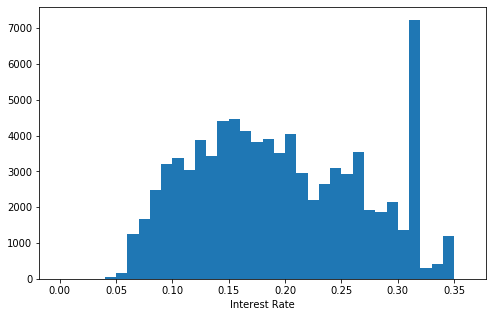

```python
# start with a standard-scaled plot
binsize = 0.01
bins = np.arange(0, df_clean['BorrowerRate'].max()+binsize, binsize)

plt.figure(figsize=[8, 5])
plt.hist(data = df_clean, x = 'BorrowerRate', bins = bins)
plt.xlabel('Interest Rate')
plt.show()
```

## 2. The Distribution of Predictor Variable

### Distribution of Prosper Rating

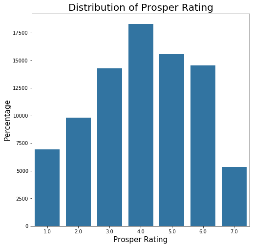

```python
base_color = sns.color_palette()[0]
plt.figure(figsize=[8, 8])
sns.countplot(data = df_clean, x='ProsperRatingNumeric',color = base_color)
plt.xticks(rotation = 0)
plt.ylabel('Percentage', size = 15)
plt.xlabel('Prosper Rating', size =15)
plt.title('Distribution of Prosper Rating', size = 20);
```

Prosper encodes their rating as follow: 1 - HR, 2 - E, 3 - D, 4 - C, 5 - B, 6 - A, 7 - AA, in which HR stands for high risk customer and AA is a customer with high credit quality. More than 20% of borrowers at Prosper have a credit grade of C. Majority of loan disbursements at Prosper come to customers who have the credit grade of D, C, B and A. Although Prosper still provides credit for high risk customer, the proportion of them is quite low.

### Distribution of Prosper Score

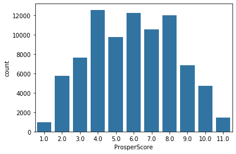

```python
base_color = sns.color_palette()[0]
prosper_score = df_clean.ProsperScore.value_counts().sort_index().index
sns.countplot(data = df_clean, x = 'ProsperScore', color = base_color, order = prosper_score)
```

### Distribution of Average Credit Score

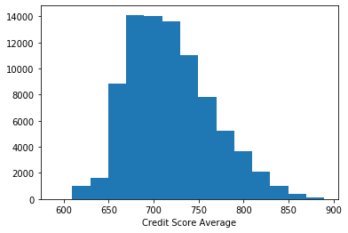

```python
binsize = 20
bins = np.arange(df_clean['CreditScoreAverage'].min() - binsize, df_clean['CreditScoreAverage'].max()+binsize, binsize)
plt.hist(data = df_clean, x = 'CreditScoreAverage', bins = bins)
plt.xlabel('Credit Score Average')
```

The distribution of Average Credit Score, which is the average of upper credit score and lower credit score, is highly concentrated between 650 and 770.

### Distribution of Monthly Stated Income

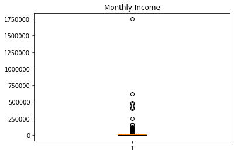

```python
fig1, ax1 = plt.subplots()
ax1.set_title('Monthly Income')
ax1.boxplot(df_clean.StatedMonthlyIncome);
```

It seems that there are outliers in monthly income. Thus, in order to make the the histogram, I will limit the the value from 0 to 25000

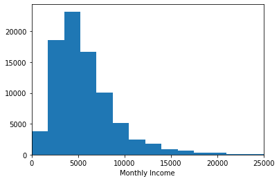

```python
plt.hist(data =df_clean, x='StatedMonthlyIncome', bins = 1000)
plt.xlabel('Monthly Income')
plt.xlim(0, 25000)
plt.show()
```

The histogram has its peak at the value of 5000. It suggests that the majority of borrowers have the income between 3000 and 7000.

### Distribution of of Term

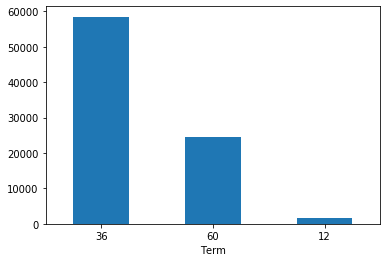

```python
df_clean.Term.value_counts().sort_values(ascending = False).plot(kind ='bar')
plt.xticks(rotation = 0)
plt.xlabel('Term')
```

Prosper has three main loan term: 12 months, 36 months and 60 months. The majority of loans are long-term, from 3 to 5 years.

### Distribution of Investors

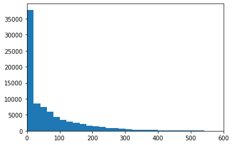

```python
binsize = 20
bins = np.arange(df_clean['Investors'].min() - binsize, df_clean['Investors'].max() + binsize, binsize)
plt.hist(data = df_clean, x='Investors', bins = bins)
plt.xlim(0,600);
```

### Distribution of Employement Status

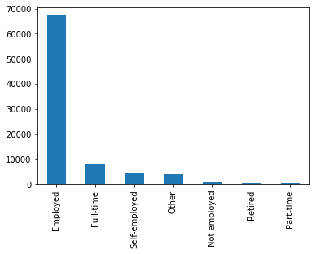

```python
# Loan by employment status

df_clean.EmploymentStatus.value_counts().sort_values(ascending = False).plot(kind ='bar')
```

Most borrower are employed, followed by full-time and self-employed.

### Distribution of Listing Category

```python
# Change the List Category from numeric to text

def encode_category(ListingCategoryNumeric):
    if ListingCategoryNumeric==0:
        category = 'Not Available'
    if ListingCategoryNumeric==1:
        category = 'Debt Consolidation'
    if ListingCategoryNumeric==2:
        category = 'Home Improvement'
    if ListingCategoryNumeric==3:
        category = 'Business'
    if ListingCategoryNumeric==4:
        category = 'Personal Loan'
    if ListingCategoryNumeric==5:
        category = 'Student Use'
    if ListingCategoryNumeric==6:
        category = 'Auto'
    if ListingCategoryNumeric==7:
        category = 'Other'
    if ListingCategoryNumeric==8:
        category = 'Baby&Adoption'
    if ListingCategoryNumeric==9:
        category = 'Boat'
    if ListingCategoryNumeric==10:
        category = 'Cosmetic Procedure'
    if ListingCategoryNumeric==11:
        category = 'Engagement Ring'
    if ListingCategoryNumeric==12:
        category = 'Green Loans'
    if ListingCategoryNumeric==13:
        category = 'Household Expanses'
    if ListingCategoryNumeric==14:
        category = 'Large Purchases'
    if ListingCategoryNumeric==15:
        category = 'Medical/Dental'
    if ListingCategoryNumeric==16:
        category = 'Motorcycle'
    if ListingCategoryNumeric==17:
        category = 'RV'
    if ListingCategoryNumeric==18:
        category = 'Taxes'
    if ListingCategoryNumeric==19:
        category = 'Vacation'
    if ListingCategoryNumeric==20:
        category = 'Wedding Loans'
    return category



df_clean['ListingCategory']=df_clean['ListingCategoryNumeric'].apply(encode_category)
```

```python
#Check results
df_clean['ListingCategory'].value_counts()
```

```
Debt Consolidation    53085
Other                  9178
Home Improvement       6783
Business               5285
Auto                   2230
Household Expanses     1996
Medical/Dental         1522
Taxes                   885
Large Purchases         876
Wedding Loans           771
Vacation                768
Motorcycle              304
Student Use             263
Engagement Ring         217
Baby&Adoption           199
Cosmetic Procedure       91
Boat                     85
Green Loans              59
RV                       52
Not Available            20
Name: ListingCategory, dtype: int64
```

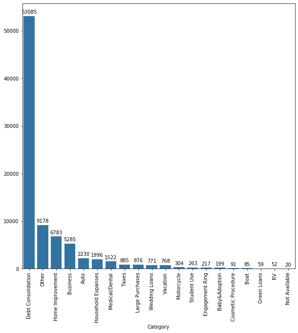

```python
base_color = sns.color_palette()[0]
category = df_clean.ListingCategory.value_counts().sort_values(ascending = False).index
category_count = df_clean.ListingCategory.value_counts()

plt.figure(figsize=[10,10])
sns.countplot(data = df_clean, x = 'ListingCategory', color = base_color, order = category)

# add annotations
locs, labels = plt.xticks() # get the current tick locations and labels

# loop through each pair of locations and labels
for loc, label in zip(locs, labels):
# get the text property for the label to get the correct count
    count = category_count[label.get_text()]
    pct_string = '{:02.0f}'.format(count)
# print the annotation just below the top of the bar
    plt.text(loc, count+500, pct_string, ha = 'center', color = 'black')

plt.xlabel('Category')
plt.ylabel('')
plt.xticks(rotation = 90)
plt.show()
```

Debt Consolidation is the most popular listing category that the borrower selected when posting their listing, followed by Home Improvement, Business, Auto, Househould Expense and Medical. There are a few of loan falls in the other categories.

### Distribution of Past Borrower

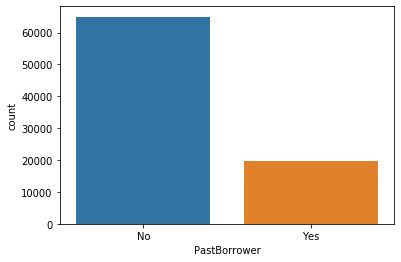

```python
sns.countplot(data = df_clean, x = 'PastBorrower')
```

New borrowers are more popular than the old one. The number of new borrowers is about 3 times more than old borrowers.

### Distribution of IsBorrowerHomeowner

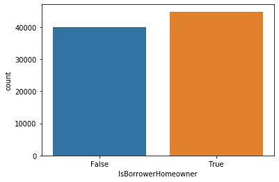

```python
sns.countplot(data = df_clean, x = 'IsBorrowerHomeowner')
```

It seems that this variable is approximately equally distributed. It suggests that about half of borrowers at Prosper own a home, other haft doesn't.

### Discuss the distribution(s) of your variable(s) of interest. Were there any unusual points? Did you need to perform any transformations?

> The interest rate takes value from 0.05 to 0.35 and does not need to perform any transformations.

## Bivariate Exploration

### To start off with, I want to look at the pairwise correlations present between features in the data.

```python
numeric_vars = ['BorrowerRate','ProsperScore', 'CreditScoreAverage','StatedMonthlyIncome','Term','Investors']
categoric_vars = ['ProsperRatingNumeric','EmploymentStatus', 'ListingCategory', 'IsBorrowerHomeowner', 'PastBorrower']
```

### 1. Correlation Matrix

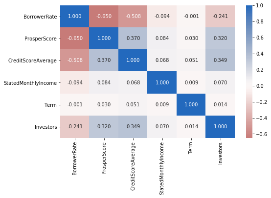

```python
# correlation plot
plt.figure(figsize = [8, 5])
sns.heatmap(df_clean[numeric_vars].corr(), annot = True, fmt = '.3f',
           cmap = 'vlag_r', center = 0)
plt.show()
```

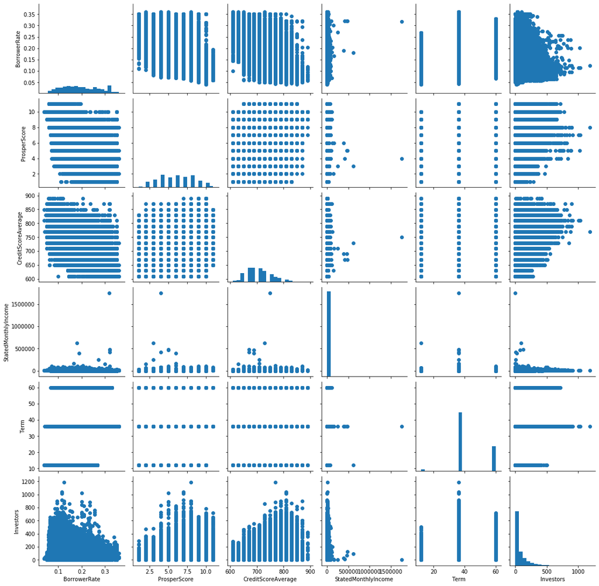

```python
# plot matrix of numeric variables

g = sns.PairGrid(data = df_clean, vars = numeric_vars)
g = g.map_diag(plt.hist, bins = 20);
g.map_offdiag(plt.scatter)
```

As expected, Prosper Score, Credit Score Avearge are highly correlated with interest rate. This will be worth extra exploration in this section. However, the correlation between interest rate and monthly stated income, term and investment is very weak. Thus, I won't perform any further analyses with these variables since they don't look like they'll be of much further interest.

### 2. Interest Rate vs Categorical Variables

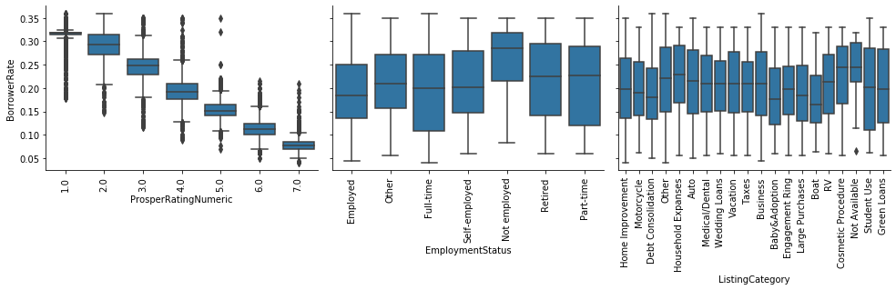

```python
# plot matrix of numeric features against categorical features.

def boxgrid1(x, y, **kwargs):
    """ Quick hack for creating box plots with seaborn's PairGrid. """
    default_color = sns.color_palette()[0]
    sns.boxplot(x, y, color = default_color)
    plt.xticks(rotation =90)


plt.figure(figsize = [10, 10])
g = sns.PairGrid(data =df_clean, y_vars = ['BorrowerRate'], x_vars = categoric_vars[0:3],
                height = 3, aspect = 1.5)

g.map(boxgrid1)
plt.show();
```

It appears to have a negative relationship between Proper rating and interest rate. The loan with a higher rating or with higher credit quality will have a lower interest rate. Employed borrowers has the lowest mean of interest. Borrowers who are unemployed tend to have a higher interest rate. The innerquartile range of interest of full-time and part-time borrowers is larger than others. It seems that different listing category will have different average and innerquartile interest rate. This is interesting that I would like to explore.

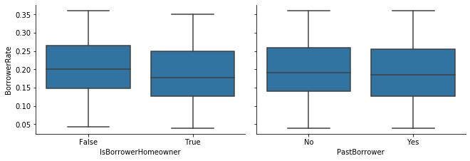

```python
def boxgrid2(x, y, **kwargs):
    """ Quick hack for creating box plots with seaborn's PairGrid. """
    default_color = sns.color_palette()[0]
    sns.boxplot(x, y, color = default_color)

plt.figure(figsize = [10, 10])
g = sns.PairGrid(data =df_clean, y_vars = ['BorrowerRate'], x_vars = categoric_vars[3: 5],
                 height = 3, aspect = 1.5)
g.map(boxgrid2)
plt.show();
```

It appears that borrowers who own a home tend to have lower interest rate on average. However, the fact that borrower is an old customer at Propers seems not to affect the interest rate they have to pay.

### 2.3. Relationships between Employment Status, Prosper Rating and Listing Category

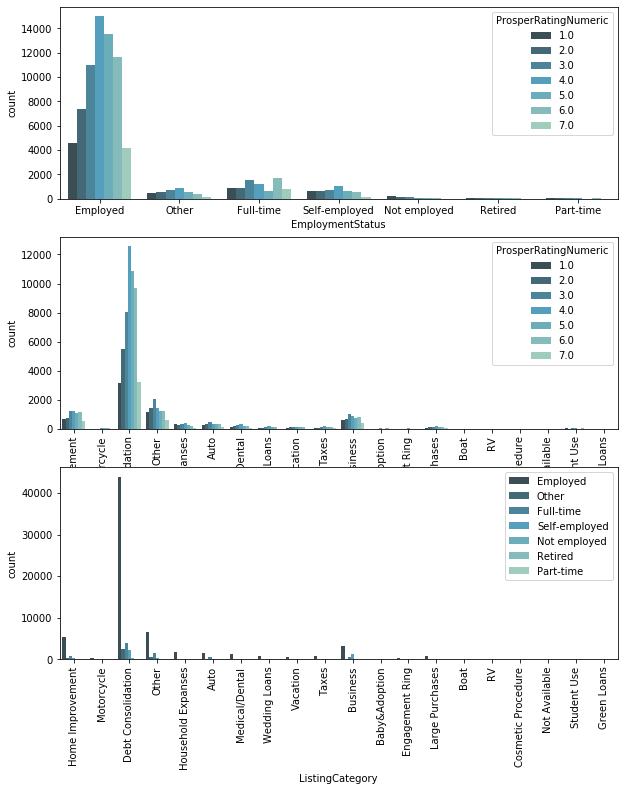

```python
# plot categoric features
plt.figure(figsize = [10, 12])

# subplot 1: Employment Status vs Prosper Rating
plt.subplot(3, 1, 1)
sns.countplot(data = df_clean, x = 'EmploymentStatus', hue ='ProsperRatingNumeric' , palette = 'GnBu_d')


# subplot 2: Listing Category vs Prosper Rating
ax = plt.subplot(3, 1, 2)
sns.countplot(data = df_clean, x ='ListingCategory', hue = 'ProsperRatingNumeric' , palette = 'GnBu_d')
plt.xticks(rotation =90)
#plt.tight_layout()

# subplot 3: Lising Category vs Employment Status
ax = plt.subplot(3, 1, 3)
sns.countplot(data = df_clean, x = 'ListingCategory', hue = 'EmploymentStatus', palette = 'GnBu_d')
plt.xticks(rotation =90)
plt.legend(loc='upper right')
plt.show()
```

Most of borrowers are employed.It looks like that many employed people resquest a loan at Prosper for their debt consolidation.

### With the preliminary look at bivariate relationships out of the way, I want to dig into some of the relationships more. First, I want to see how interest rate and average credit score are related to one another.

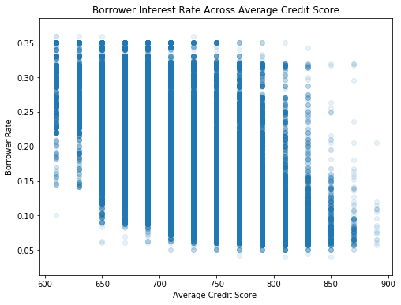

```python
# scatter plot of borrower rate vs. average credit score

plt.figure(figsize = [8, 6])
plt.scatter(data = df_clean, x = 'CreditScoreAverage', y = 'BorrowerRate', alpha = 1/10)
plt.xlabel('Average Credit Score ')
plt.ylabel('Borrower Rate')
plt.title('Borrower Interest Rate Across Average Credit Score');
```

People who have an low average credit score, which is between 600 and 630, must pay highest rate. Most of them have to pay interest rate between 20% to 35%. On the other hand, most of high credit quality borrowers who have average credit score higher than 830 only pay interest rate below 15%. For medium risk borrowers, the rating score seems to have no strong relationship with the interest rate that they have to pay.

### Secondly, the relationship between Prosper Score and Borrower Rate

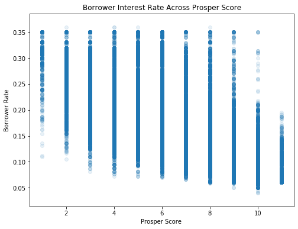

```python
# scatter plot of borrower rate vs. Prosper score

plt.figure(figsize = [8, 6])
plt.scatter(data = df_clean, x = 'ProsperScore', y = 'BorrowerRate', alpha = 1/10)
plt.xlabel('Prosper Score ')
plt.ylabel('Borrower Rate')
plt.title('Borrower Interest Rate Across Prosper Score');
```

We can see the same pattern with Prosper Score. The difference in interest rate is only clear if the borrowers are high risk or high credit quality.

### What do we obrserve after Bivariate Exploration?

> Interest rate have a correlation with Proper Rating and Average Credit Score. However, this relationship is only clear if the rating or credit score is really high or really low. In other words, if borrowers are very high risk, they are penalized by higher interest rates. On the other hand, if borrowers are very low credit risk, they entitile low borrowing rate. For customer wtih medium risk, there is no clear pattern.

## Multivariate Exploration

### The main thing I want to explore in this part of the analysis is how the three categorical measures relate to the borrower rate

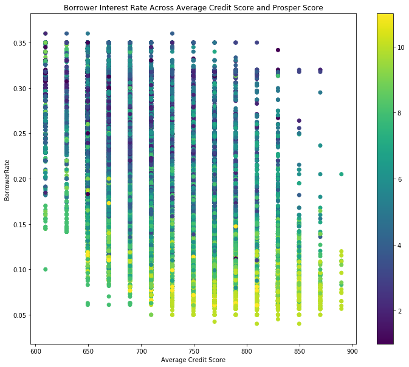

```python
plt.figure(figsize =(12,10))
plt.scatter(data = df_clean, x = 'CreditScoreAverage', y = 'BorrowerRate', c = 'ProsperScore')
plt.xlabel('Average Credit Score')
plt.ylabel('BorrowerRate')
plt.title('Borrower Interest Rate Across Average Credit Score and Prosper Score')
plt.colorbar();
```

The scatter plot between BorrowerRate and CreditScoreAverage with ProsperScore as color encoded emphasizes the relationship between interest rate and Credit Rating of customers, especially customers who have a very high or very low credit rating.

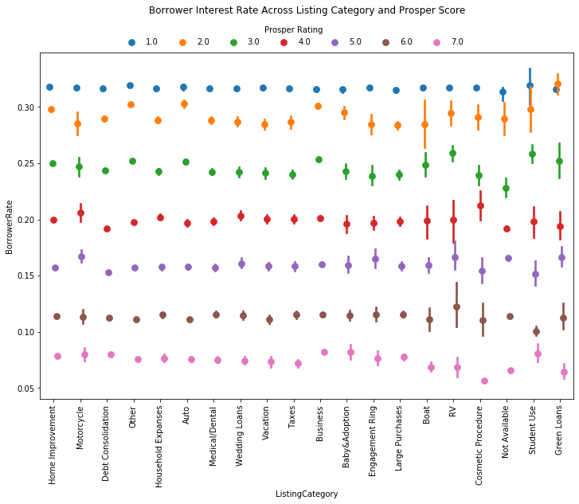

```python
plt.figure(figsize=(12,8))
ax = sns.pointplot(data = df_clean, x = 'ListingCategory', y ='BorrowerRate' , hue = 'ProsperRatingNumeric',
                  dodge = 0.3, linestyles = "")

plt.xticks(rotation = 90)
plt.title('Borrower Interest Rate Across Listing Category and Prosper Score', y = 1.1)
ax.legend(loc='lower left', bbox_to_anchor= (0.15, 1.01), ncol=7,
            borderaxespad=0, frameon=False, title = 'Prosper Rating')
```

As can be seen from the graph, the relationship between interest rate and Prosper rating which is mentioned before has been clearly reflected to diffterent listing category. The higher Prosper rating borrowers have, the lower interest rate they have to pay. Popular types of lisiing category, for example, debt consolidation, home improvement, auto, business and medical, have a very low standard deviation of interest rate. Some categories, for example, Motocycle, Baby & Adpotion, Engagement Ring, Boat, BV, Cosmetic Procedure, Student Use and Green Loans have a lagre error bar because of limited entries in this data set. However, this graph is not so useful because there is no clear different in interest rate between borrowwers who have the same credit rating level but different listing category.

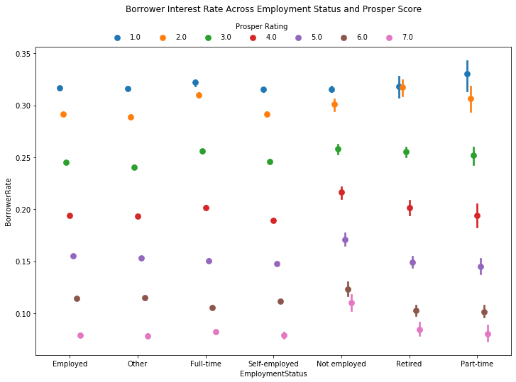

```python
plt.figure(figsize=(12,8))
ax = sns.pointplot(data = df_clean, x = 'EmploymentStatus', y ='BorrowerRate' , hue = 'ProsperRatingNumeric',
                  dodge = 0.3, linestyles = "")
plt.title('Borrower Interest Rate Across Employment Status and Prosper Score', y = 1.1)
ax.legend(loc='lower left', bbox_to_anchor= (0.15, 1.01), ncol=7,
            borderaxespad=0, frameon=False, title = 'Prosper Rating')
```

In this graph, there is also no clear difference in interest rate between borrowers who have the same credit rating but different employment status. The standard deviation in unemployed, retired and part-time group is higher because of limited entries in this data set.

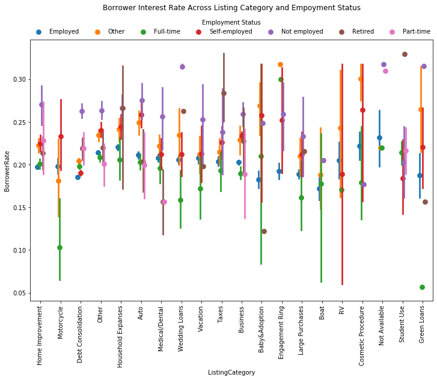

```python
# I also want to have a look at borrower rate, listing category and employment status.

plt.figure(figsize=(12,8))
ax = sns.pointplot(data = df_clean, x = 'ListingCategory', y ='BorrowerRate' , hue ='EmploymentStatus' ,
                  dodge = 0.3, linestyles = "")
plt.xticks(rotation = 90)
plt.title('Borrower Interest Rate Across Listing Category and Empoyment Status', y = 1.1)
ax.legend(loc='lower left', bbox_to_anchor= (0, 1.01), ncol=7,
            borderaxespad=0, frameon=False, title = 'Employment Status')
```

Because of unequally distributed of the loan across the different listing categories, the error bar of borrower rate when visualizing using point plot is large for the different employment statuses of less popular categories. However, let focus on the most popular listing category at Prosper - Debt Consolidation, which accounts for 60% of loan.

If the listing category is debt consolidation, employed borrowers have to pay the lowest interest rate, followed by self-employed and full-time borrowers. The interest rate for unemployed borrowers is the highest.

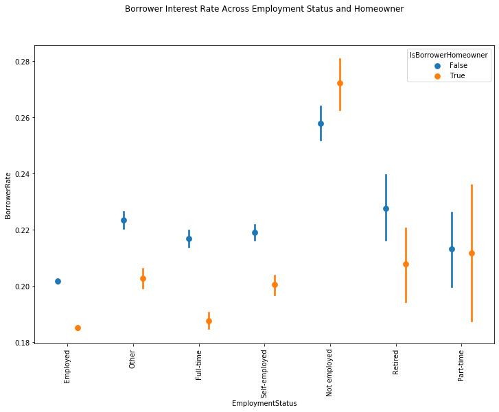

```python
# Borrower rate vs Employment Status and Homeowner
plt.figure(figsize=(12,8))
ax = sns.pointplot(data = df_clean, x = 'EmploymentStatus', y ='BorrowerRate' , hue = 'IsBorrowerHomeowner',
                  dodge = 0.3, linestyles = "")

plt.xticks(rotation = 90)
plt.title('Borrower Interest Rate Across Employment Status and Homeowner', y = 1.1)
```

### What do we observe in this multivariate investigation?

> I extended my investigation of interest rate against credit rating by looking at the impact of categorical features. The multivariate exploration showed that there is a negative relation ship between the credit rating and interest rate. The higher credit rating, the lower interest rate. However, there is no clear different in interest rate of borrower who have the same credit rating but different listing category or employment status. When borrowers own a home, they pay lower interest if their employment status is employed, fulltime or self-employed. It is completely inverse for unemployed borrowers.

```python
df_clean.to_csv('prosper_clean.csv', index = False)
```